# Deep learning-based precision agriculture through weed recognition in sugar beet fields - ScienceDirect

View **PDF**

[figure not shown]

- Access through **your institution**

## Figures (10)

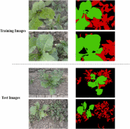

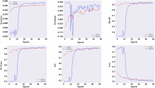

## Tables (2)

[figure not shown]

## [Sustainable Computing: Informatics and Systems](https://www.sciencedirect.com/journal/sustainable-computing-informatics-and-systems)

[Volume 35](https://www.sciencedirect.com/journal/sustainable-computing-informatics-and-systems/vol/35/suppl/C), September 2022, 100759

# Deep learning-based precision agriculture through weed recognition in sugar beet fields

https://doi.org/10.1016/j.suscom.2022.100759[Get rights and content](https://s100.copyright.com/AppDispatchServlet?publisherName=ELS&contentID=S2210537922000919&orderBeanReset=true)

## Highlights

**•**

ResNet50-based U-Net was utilized for the semantic segmentation of sugar beet, weed, and soil.

**•**

Two different structures of the dataset were employed for the training and testing steps.

**•**

A combination of the dice and focal losses was used as a custom linear loss function.

**•**

The semantic segmentation model achieved an accuracy of 0.9606.

## Abstract

Weeds are among the major factors adversely affecting crop yield. Therefore, weed control with minimal environmental damage is a global concern. Traditional weed [control methods](https://www.sciencedirect.com/topics/computer-science/control-method) are not cost-effective. Hence, precision agriculture proposes variable flow herbicide technology through regional weed management to distinguish weed and crop. In the present study, we employed the U-Net architecture, as a deep encoder-decoder convolutional neural network (CNN) for pixel-wise semantic segmentation of sugar beet, weed, and soil. We trained the U-Net architecture with ResNet50 as the encoder block using 1385 RGB images collected under different conditions and various heights. We utilized the combination of the dice and focal losses as a custom linear loss function to overcome [imbalanced data](https://www.sciencedirect.com/topics/computer-science/imbalanced-data) and small area segmentation challenges. The structure of the dataset for the training process and using the custom loss function led to a model with the accuracy and intersection over union (IoU) score of 0.9606 and 0.8423, respectively. The results showed that using the image dataset with proper distribution and custom loss function can improve segmentation accuracy, especially in small regions. Furthermore, in an autonomous weed control robot, CNN-based automatic weed detection can be integrated into selective herbicide applications.

## Keywords

Sugar beet

Weed detection

Semantic segmentation

Deep learning

## Cited by (0)

[View full text](https://www.sciencedirect.com/science/article/pii/S2210537922000919)

© 2022 Elsevier Inc. All rights reserved.

[figure not shown]

[figure not shown]